# Coding for Intelligence Analysis

## Exploratory Data Analytics of Crimes commited in South Australia in the year 2021

### Import Libraries

```python
import pandas as pd
import warnings
warnings.filterwarnings('ignore')
import seaborn as sns
import matplotlib.pyplot as plt
import numpy as np
```

### Data Collection and Handling

#### Background

##### Crimes and Economic growth

> According to the economic theory, crime will generally decrease with the improvement of economic growth and opportunity in a country. Essentially, this argument follows the asumption that the incentive to take part in illegal activities will decrease as legal avenues of earning income become more available and accessible to the public (Street, 2019). However, Street (2019) argues that there are documented cases where economic growth has led to higher crime rates.

> To a large extent, Criminal activity acts like a tax on the entire economy of a given country: whether directly or indirectly, crimes tend to discourage both domestic and foreign direct investments, besides affecting the competetiveness of firms, and reallocates resources creating uncertainty and inefficiency (Detotto & Otranto, 2010). Therefore, reduction of crime is among the central objectives of any given authority as a means of attracting entrepreneurial activities, investment, etcetera in a bid to facilitate the generation of employment and subsequently reducing poverty level and improving standards of living. This observation is supported by Teresa (2018) who notes that, "...The necessity for effective crime prevention measures to reduce criminal activity and increase public safety is being recognized as a priority in many countries"

> There exists a number of crime-combating strategies some of which include vocational training for older offenders, monitoring by special units for high-risk repeat offenders, arrests, etcetera. However, to fully combat crime it is essential that the dynamics of crime in the area under focus is fully understood. One such method with which to understand the dynamics of crime is through the utilization of data analytics tools (Cavallaro, et al., 2020).

##### Crime and Data Analytics

> A simple google for the phrase "crime and data analytics" returns approximately 242,000,000 results which ideally points to the observation of the interest accorded to the two concepts. According to a study by Sri (2021), “…Modern data analytics uses machine learning to identify patterns and create more accurate criminal profiles in significantly less time, which can then be used to capture criminals.” Various approaches have been adopted in the process of utilizing data to understand crime dynamics depending on the underlying aspect i.e., regional analysis of crime or even analyzing a specific type of crime. Data analysis using big data has equally attracted considerable interest. Crimes that have been explored by previous studies using big data technologies including but not limited to data mining and predictive analytics include fraud, smuggling, money laundering, identity theft, and murder etctera.

> Matthews (2017) argues that concerning the question of whether big data can be utilized to allow the prevention of crime, big data can enable law enforcement to better prepare and come up with preplanned missions, facilitate the nabbing of criminals at the opportune moment, thus preventing further crimes from taking place. In her article, (Matthews, 2017) observes that one such program was adopted by the Los Angeles Police Department (LAPD) to reduce crime in the Los Angeles metropolitan area, and it worked.

##### Objective

> The objective of the current study is to examine the demographic distribution of crimes reported in Southern Australia. In particular, the current study seeks to determine the regions that have the most crimes and those that have relatively few crimes. Besides, the current work will examine the trend exhibited by the number reported crimes in South Australia.

#### Methods

##### Data

> To address the current research problem, a secondary data collection approach was adopted where data related to the reported crimes in South Australia was collected. Additional data that provides information on the names of the postal codes included in the crime data was collected. Below is a description of the collected data.

> Since the objective of the current study is to examine the behavior of the reported crimes in 2021, the data will be filtered off to include only the information related to the crimes reported in the year of research interest.

###### Data Description

> Suburb-based crime statistics for crimes against the person and crimes against property.

Datasets have been enhanced to include sexual assault and related offences in a way that excludes location to ensure confidentiality for victims of those offences.

> Crime data was collected from https://data.sa.gov.au/data/datastore/dump/e0b8d120-65e3-44e6-9e2e-aeb7aec59114?bom=True

> Post code data was collected from https://www.worldpostalcodes.org/l1/en/au/australia/list/r1/list-of-postcodes-in-south-australia

#### Import Data

```python
#crime data
df = pd.read_csv('data/crime data south australia.csv')
#post data
post = pd.read_csv('data/post codes sa.txt', sep = '\t')
```

```python
df.head()
```

|  | _id | Reported Date | Suburb - Incident | Postcode - Incident | Offence Level 1 Description | Offence Level 2 Description | Offence Level 3 Description | Offence count |
| --- | --- | --- | --- | --- | --- | --- | --- | --- |
| 0 | 1 | 01/07/2020 | ABERFOYLE PARK | 5159 | OFFENCES AGAINST PROPERTY | FRAUD DECEPTION AND RELATED OFFENCES | Obtain benefit by deception | 1.0 |
| 1 | 2 | 01/07/2020 | ADELAIDE | 5000 | OFFENCES AGAINST PROPERTY | PROPERTY DAMAGE AND ENVIRONMENTAL | Graffiti | 3.0 |
| 2 | 3 | 01/07/2020 | ADELAIDE | 5000 | OFFENCES AGAINST PROPERTY | PROPERTY DAMAGE AND ENVIRONMENTAL | Other property damage and environmental | 2.0 |
| 3 | 4 | 01/07/2020 | ADELAIDE | 5000 | OFFENCES AGAINST PROPERTY | THEFT AND RELATED OFFENCES | Other theft | 2.0 |
| 4 | 5 | 01/07/2020 | ADELAIDE | 5000 | OFFENCES AGAINST PROPERTY | THEFT AND RELATED OFFENCES | Receive or handle proceeds of crime | 1.0 |

```python
post.head()
```

|  | Postcode Code | Postcode Name | Local Government Area |
| --- | --- | --- | --- |
| 0 | 5000 | Adelaide | Adelaide |
| 1 | 5006 | Adelaide | Adelaide |
| 2 | 5007 | Charles Sturt | Charles Sturt |
| 3 | 5008 | Charles Sturt | Charles Sturt |
| 4 | 5009 | Charles Sturt | Charles Sturt |

##### Check general data information

```python
df.info()
```

```
<class 'pandas.core.frame.DataFrame'>
RangeIndex: 84949 entries, 0 to 84948
Data columns (total 8 columns):
 #   Column                       Non-Null Count  Dtype
---  ------                       --------------  -----
 0   _id                          84949 non-null  int64
 1   Reported Date                84948 non-null  object
 2   Suburb - Incident            84229 non-null  object
 3   Postcode - Incident          84163 non-null  object
 4   Offence Level 1 Description  84948 non-null  object
 5   Offence Level 2 Description  84948 non-null  object
 6   Offence Level 3 Description  84948 non-null  object
 7   Offence count                84948 non-null  float64
dtypes: float64(1), int64(1), object(6)
memory usage: 5.2+ MB
```

```python
post.info()
```

```
<class 'pandas.core.frame.DataFrame'>
RangeIndex: 341 entries, 0 to 340
Data columns (total 3 columns):
 #   Column                 Non-Null Count  Dtype
---  ------                 --------------  -----
 0   Postcode Code          341 non-null    int64
 1   Postcode Name          341 non-null    object
 2   Local Government Area  341 non-null    object
dtypes: int64(1), object(2)
memory usage: 8.1+ KB
```

#### Evaluation of data quality

> During checking the quality of the data, the process will involve checking if there are any missing observations as well as treating the missing observations appropriately.

```python
df.isna().sum()
```

```
_id                              0
Reported Date                    1
Suburb - Incident              720
Postcode - Incident            786
Offence Level 1 Description      1
Offence Level 2 Description      1
Offence Level 3 Description      1
Offence count                    1
dtype: int64
```

```python
df.columns
```

```
Index(['_id', 'Reported Date', 'Suburb - Incident', 'Postcode - Incident',
       'Offence Level 1 Description', 'Offence Level 2 Description',
       'Offence Level 3 Description', 'Offence count'],
      dtype='object')
```

##### Proportion of missing observations

```python
percent_missing = df.isna().sum() * 100 / len(df)
missing_value_df = pd.DataFrame({'column_name': df.columns,
                                 'percent missing': percent_missing})
missing_value_df.sort_values('percent missing', inplace=True)
missing_value_df.drop('column_name', axis = 1)
```

|  | percent missing |
| --- | --- |
| _id | 0.000000 |
| Reported Date | 0.001177 |
| Offence Level 1 Description | 0.001177 |
| Offence Level 2 Description | 0.001177 |
| Offence Level 3 Description | 0.001177 |
| Offence count | 0.001177 |
| Suburb - Incident | 0.847567 |
| Postcode - Incident | 0.925261 |

##### Clean the data's missing observations

> Since we can not assume postcodes and suburb, the missing observations will be excluded to avoid introducing bias into the data. However, this might lead to an under-representation of the crime situation in South Australia.

```python
#Clean missing values
df1 = df.dropna()
percent_missing = df1.isna().sum() * 100 / len(df1)
missing_value_df1 = pd.DataFrame({'column_name': df1.columns,
                                 'percent missing': percent_missing})
missing_value_df1.sort_values('percent missing', inplace=True)
missing_value_df1.drop('column_name', axis = 1)
```

|  | percent missing |
| --- | --- |
| _id | 0.0 |
| Reported Date | 0.0 |
| Suburb - Incident | 0.0 |
| Postcode - Incident | 0.0 |
| Offence Level 1 Description | 0.0 |
| Offence Level 2 Description | 0.0 |
| Offence Level 3 Description | 0.0 |
| Offence count | 0.0 |

```python
df1.info()
```

```
<class 'pandas.core.frame.DataFrame'>
Int64Index: 84160 entries, 0 to 84946
Data columns (total 8 columns):
 #   Column                       Non-Null Count  Dtype
---  ------                       --------------  -----
 0   _id                          84160 non-null  int64
 1   Reported Date                84160 non-null  object
 2   Suburb - Incident            84160 non-null  object
 3   Postcode - Incident          84160 non-null  object
 4   Offence Level 1 Description  84160 non-null  object
 5   Offence Level 2 Description  84160 non-null  object
 6   Offence Level 3 Description  84160 non-null  object
 7   Offence count                84160 non-null  float64
dtypes: float64(1), int64(1), object(6)
memory usage: 5.8+ MB
```

#### Merge the crime and postal data

> Merge the crime and post data to obtain the names of the postcodes where the srimes happened.

```python
#convert
df1['Postcode Code'] = pd.to_numeric(df1['Postcode - Incident'], errors = 'coerce')
#merge the dataset
df2 = df1.merge(post)
#fill the missing most codes with not disclosed
df2['Postcode Code'] = df2[['Postcode Code']].fillna(value='Not Disclosed')
df2.info()
```

```
<class 'pandas.core.frame.DataFrame'>
Int64Index: 82919 entries, 0 to 82918
Data columns (total 11 columns):
 #   Column                       Non-Null Count  Dtype
---  ------                       --------------  -----
 0   _id                          82919 non-null  int64
 1   Reported Date                82919 non-null  object
 2   Suburb - Incident            82919 non-null  object
 3   Postcode - Incident          82919 non-null  object
 4   Offence Level 1 Description  82919 non-null  object
 5   Offence Level 2 Description  82919 non-null  object
 6   Offence Level 3 Description  82919 non-null  object
 7   Offence count                82919 non-null  float64
 8   Postcode Code                82919 non-null  float64
 9   Postcode Name                82919 non-null  object
 10  Local Government Area        82919 non-null  object
dtypes: float64(2), int64(1), object(8)
memory usage: 7.6+ MB
```

#### Subset data to obtain observations for the year 2021

> Filter the data to include only the year of interest.

```python
m = df2['Reported Date'].str.contains('2021')
df2 = df2[m]
```

```python
#convert upper case entries to title case
df2 = df2.apply(lambda x: x.str.title() if x.dtype == "object" else x)
```

#### Exploratory data analysis

> The objective of the exploratory analysis is to:
1. Determine the distribution of reported crimes across surburbs, post codes where the incident occurred, the various offence levels.
2. Examine the distribution of crimes through cross-tabulation on different levels including offence level 1, 2, and 3 descriptions
3. Examine the change in levels of crime in the 2020-2021

### Distribution of crimes

#### Crimes per postcode name

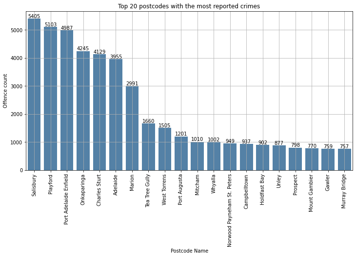

```python
post_crimes = pd.DataFrame(df2.groupby('Postcode Name')['Offence count'].sum()).reset_index()
#sort by total crimes per post code
post_crimes = post_crimes.sort_values('Offence count', ascending = False)
plt.rcParams['figure.figsize'] = 12, 6
chart = sns.barplot(x = 'Postcode Name', y = 'Offence count', data = post_crimes.head(20), color = 'steelblue')
plt.grid()
plt.xticks(rotation = 90)
chart.bar_label(chart.containers[0])
plt.title('Top 20 postcodes with the most reported crimes')
plt.show()
```

> From the plot above, the data shows that Salisbury (5405), Playford (5103), and Port Adeleide Enfield (4987) had the highest number of reported crimes in the year 2021 while Elliston (7), Cleve (7), and Kimba (5) had the least number of crimes reported in year 2021 (*see the plot below*).

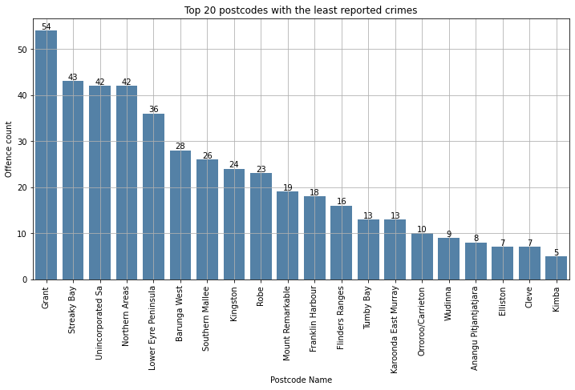

```python
post_crimes = pd.DataFrame(df2.groupby('Postcode Name')['Offence count'].sum()).reset_index()
#sort by total crimes per post code
post_crimes = post_crimes.sort_values('Offence count', ascending = False)
plt.rcParams['figure.figsize'] = 12, 6
chart = sns.barplot(x = 'Postcode Name', y = 'Offence count',
                    data = post_crimes.tail(20), color = 'steelblue')
plt.grid()
plt.xticks(rotation = 90)
plt.title('Top 20 postcodes with the least reported crimes')
chart.bar_label(chart.containers[0])
plt.show()
```

#### Crimes per Suburb

> Examining the number of crimes per sururb, it is noted that Adelaide had the highest number of crimes (*see the plot below*) with a total of up to 3582 which is relatievly high compared to the number of crimes reported in the Morphette (820) and Port Augusta (799) which have the second and third highest number of reported crimes.

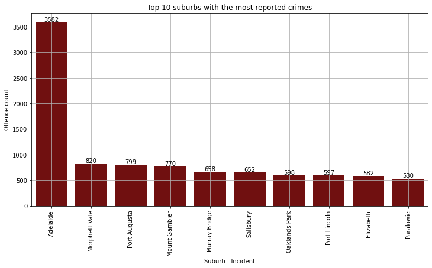

```python
suburb_crimes = pd.DataFrame(df2.groupby('Suburb - Incident')['Offence count'].sum()).reset_index()
#sort by total crimes per suburb code
suburb_crimes = suburb_crimes.sort_values('Offence count', ascending = False)
plt.rcParams['figure.figsize'] = 12, 6
chart = sns.barplot(x = 'Suburb - Incident', y = 'Offence count',
                    data = suburb_crimes.head(10), color = 'maroon')
plt.grid()
plt.xticks(rotation = 90)
chart.bar_label(chart.containers[0])
plt.title('Top 10 suburbs with the most reported crimes')
plt.show()
```

> Some suburbs as shown in the figure below had as little as 1 crime reported in the entire year. That is, out of the 1031 suburbs, 188 has 1 crime reported in 2021 with up to 460 suburbs having at most 5 crimes recorded in 2021.

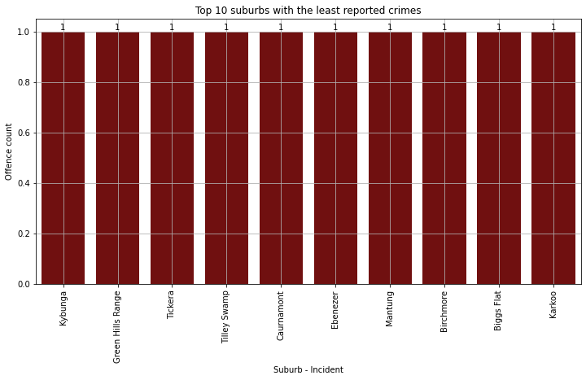

```python
suburb_crimes = pd.DataFrame(df2.groupby('Suburb - Incident')['Offence count'].sum()).reset_index()
#sort by total crimes per suburb code
suburb_crimes = suburb_crimes.sort_values('Offence count', ascending = False)
plt.rcParams['figure.figsize'] = 12, 6
chart = sns.barplot(x = 'Suburb - Incident', y = 'Offence count',
                    data = suburb_crimes.tail(10), color = 'maroon')
plt.grid()
plt.xticks(rotation = 90)
chart.bar_label(chart.containers[0])
plt.title('Top 10 suburbs with the least reported crimes')
plt.show()
```

```python
pd.DataFrame(suburb_crimes['Offence count'].value_counts()).head()
```

|  | Offence count |
| --- | --- |
| 1.0 | 188 |
| 2.0 | 125 |
| 3.0 | 74 |
| 4.0 | 41 |
| 5.0 | 32 |

#### Proportion Distribution per crime target

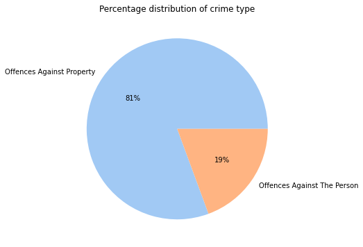

```python
#data
offence1 = pd.DataFrame(df2.groupby('Offence Level 1 Description')['Offence count'].sum())
offence1 = offence1.reset_index()
data = offence1['Offence count'].values
labels = offence1['Offence Level 1 Description'].values

#color palette to use
colors = sns.color_palette('pastel')[0:5]

#plot pie chart
plt.pie(data, labels = labels, colors = colors, autopct='%.0f%%')
plt.title('Percentage distribution of crime type')
plt.show()
```

> Data shows that 81% of the crimes recored in 2021 they were targeted on properties while 19% targeted individuals. Similarly it is noted that majority of the crimes i.e., the top 3 reported crimes were *Theft and related offences* (45%), *Property damage and environmental* (20%) as well as *Acts intended to cause injury* (18%) (*see the figure below*).

#### Proportion of crime by crime level

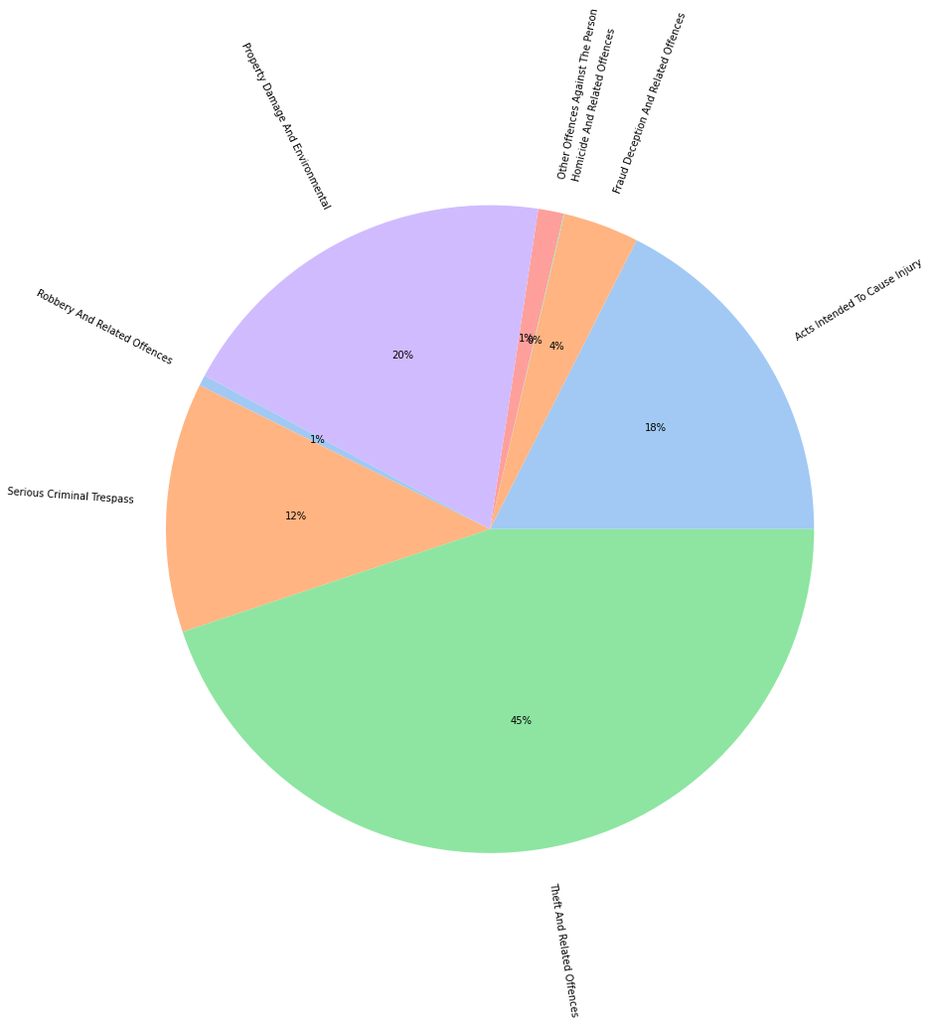

```python
#data
offence1 = pd.DataFrame(df2.groupby('Offence Level 2 Description')['Offence count'].sum())
offence1 = offence1.reset_index()
data = offence1['Offence count'].values
labels = offence1['Offence Level 2 Description'].values

#color palette to use
colors = sns.color_palette('pastel')[0:5]

#plot pie chart
plt.rcParams['figure.figsize'] = 20, 15
plt.pie(data, labels = labels, colors = colors, autopct='%.0f%%', rotatelabels=True)
#plt.title('Percentage distribution of crime type')
plt.yticks(rotation = 90)
plt.show()
```

#### Distribution of crimes per crime type

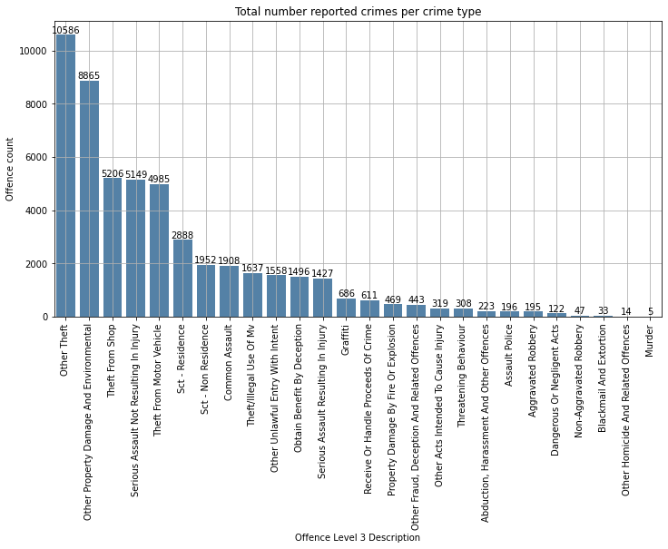

```python
#data
offence3 = pd.DataFrame(df2.groupby('Offence Level 3 Description')['Offence count'].sum())
offence3 = offence3.reset_index()
#sort by total crimes per post code
offence3 = offence3.sort_values('Offence count', ascending = False)
plt.rcParams['figure.figsize'] = 12, 6
chart = sns.barplot(x = 'Offence Level 3 Description', y = 'Offence count',
                    data = offence3, color = 'steelblue')
plt.grid()
plt.xticks(rotation = 90)
plt.title('Total number reported crimes per crime type')
chart.bar_label(chart.containers[0])
plt.show()
```

```python
offence3['Offence count'].head(3).sum()
```

```
24657.0
```

#### Trend of crimes in the year 2020-2021

> The objective is to establish whether the number of crimes reported in South Australia were increasing throughout the year. To do so, a trend plot will be generate besides using the Mann-Kendall Trend Test to determine whether the observed trend is significant. In practice, the Mann-Kendall Trend Test analyzes difference in signs between previous and subsequent data observations. The theory behind the test is that if a trend exists, the sign values will generally tend to increase constantly, or decrease constantly.

```python
#Get total number of crimes per day
month_crime = pd.DataFrame(df2.groupby('Reported Date')['Offence count'].sum())
month_crime = month_crime.reset_index()
#covert date reported to datetime
month_crime['Reported Date'] = pd.to_datetime(month_crime['Reported Date'])

#overview of the crimes per day
month_crime.head()
```

|  | Reported Date | Offence count |
| --- | --- | --- |
| 0 | 2021-01-01 | 349.0 |
| 1 | 2021-01-02 | 302.0 |
| 2 | 2021-01-03 | 348.0 |
| 3 | 2021-01-04 | 279.0 |
| 4 | 2021-01-05 | 297.0 |

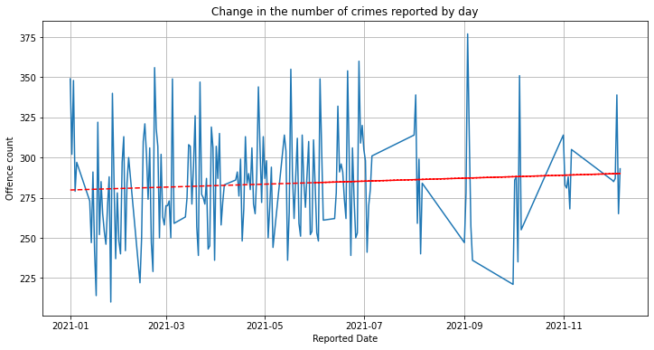

```python
sns.lineplot(x="Reported Date", y="Offence count", data = month_crime);
import matplotlib.dates as mdates

x = mdates.date2num(month_crime['Reported Date'])

y = month_crime['Offence count']
plt.rcParams['figure.figsize']=(12,10)
z = np.polyfit(x, y, 1)
p = np.poly1d(z)
plt.plot(x,p(x),"r--")
plt.grid()
plt.title('Change in the number of crimes reported by day')
plt.show()
```

```python
month_crime.sort_values('Offence count', ascending = False)
```

|  | Reported Date | Offence count |
| --- | --- | --- |
| 50 | 2021-09-03 | 377.0 |
| 167 | 2021-06-28 | 360.0 |
| 127 | 2021-02-22 | 356.0 |
| 100 | 2021-05-17 | 355.0 |
| 125 | 2021-06-21 | 354.0 |
| ... | ... | ... |
| 121 | 2021-02-21 | 229.0 |
| 73 | 2021-02-13 | 222.0 |
| 54 | 2021-10-01 | 221.0 |
| 96 | 2021-01-17 | 214.0 |
| 150 | 2021-01-26 | 210.0 |

181 rows × 2 columns

> From the line plot above (*observe the red line*), it is noted that there is a slight increasing trend in the number of crimes reported throughout 2021. From the plot, it is observed that the top 3 days with the most crimes were September 3rd (377), June 28th (360), and February 22nd (356)

#### Test to determine whether or not a trend exists in number of reported crimes over time

> The hypotheses for the test are as follows:

```
H0 (null hypothesis): There is no trend present in the data.

HA (alternative hypothesis): A trend is present in the data. (This could be a positive or negative trend)
```

> If the p-value of the test is lower than some significance level (common choices are 0.10, 0.05, and 0.01), then there is statistically significant evidence that a trend is present in the time series data.

```python
#uncomment to install the library to conduct trend test
#!pip install pymannkendall

#perform Mann-Kendall Trend Test
import pymannkendall as mk
mk.original_test(y)
```

```
Mann_Kendall_Test(trend='no trend', h=False, p=0.6954643208013291, z=-0.3914504320878186, Tau=-0.019643953345610803, s=-320.0, var_s=664091.3333333334, slope=-0.0196078431372549, intercept=285.7647058823529)
```

> From the results given above, the p-value is approximately 0.6954 which is not less than .05. As such, we can conclude that there is no significant trend in the number of reported crimes in the year 2021 i.e., the number of crimes tended to remain constant throughout the year.

### Conclusion

> Based on the analyses above, the following conclusions were drawn:
1. Southern Australia experiences more property crimes relative to person-targeted crimes
2. Salisbury, Playford, and Port Adeleide Enfield were the most dangerous postcodes in 2021
3. Adelaide, Morphette, and Port Augusta were the most unsafe surbubs in 2021
4. Out of the 1031 surburbs which experienced crime in 2021, 460 are comparatively safe given that they had only experienced 5 crimes in the whoe year while 188 are very safe with only a single crime reported. This implies that only 18.23% of South Australia was very safe in 2021
5. The level of crimes remained constant throughout the year indicating the crimes are not influenced by factors such as seasons.

#### General Report details

```python
import io
import warnings
warnings.filterwarnings('ignore')
from IPython.nbformat import current

with io.open('Coding for Intelligence Analysis.ipynb', 'r', encoding='utf-8') as f:
    nb = current.read(f, 'json')

word_count = 0
for cell in nb.worksheets[0].cells:
    if cell.cell_type == "markdown":
        word_count += len(cell['source'].replace('#', '').lstrip().split(' '))
print('There are',word_count, 'words in the report section')
```

```
There are 1554 words in the report section
```